# R0 estimation in Nigeria

## Links to local data sets

Here we use the following links to data.

```r
# directories
DATA_FOLDER <- file.path("..", "data")
POPULATION_DATA_FOLDER <- file.path(DATA_FOLDER, "population_data")
SPATIAL_POLYGONS_FOLDER <- file.path(DATA_FOLDER, "spatial_polygons")
RUBELLA_SEROPREVALENCE_DATA_FOLDER <- file.path(DATA_FOLDER, "seroprevalence_data")
HELPER_SCRIPTS_FOLDER <- file.path("helper_scripts")
MCMC_FITTING_OUTPUT_FOLDER <- file.path("MCMC_fitting_output")
MCMC_ESTIMATES_FOLDER <- file.path("MCMC_estimates")
FIGURES_FOLDER <- file.path("figures")

# derived data from `nigeria_data_organization_exploration.Rmd`
ng2_pop_path <- file.path(POPULATION_DATA_FOLDER, "ng2_pop.rds")
ng2_path <- file.path(SPATIAL_POLYGONS_FOLDER, "ng2.rds")
ng1_path <- file.path(SPATIAL_POLYGONS_FOLDER, "ng1.rds")
ng1_fertility_data_path <- file.path(POPULATION_DATA_FOLDER, "ng1_fertility_data.csv")
ng0_selected_mortality_rates_path <- file.path(POPULATION_DATA_FOLDER, "ng0_mortality_rates.rds")

# local data
ng1_rub_sero_path <- file.path(RUBELLA_SEROPREVALENCE_DATA_FOLDER, "ng1_rubella_seroprevalence_data.csv")
ng1_zone_mapping_path <- file.path(POPULATION_DATA_FOLDER, "ng1_zone_designations.xlsx")
```

Change them accordingly if you want to run the script locally on your computer.

## Preambule

This document focuses on estimating the $R_0$ for rubella in each state of Nigeria using age-stratified serological survey data.

The R Markdown document `nigeria_data_organization_exploration.Rmd` must be successfully run prior to this document because it is responsible for downloading and organizing the following data files: `ng2_pop.rds` (population age and sex structure at local government level), `ng2.rds` (spatial polygons at the local government level), `ng1.rds` (spatial polygons at the state level), `ng1_fertility_data.csv` (age-specific fertility rates at the state level), and `ng0_mortality_rates.rds` (piece-wise constant mortality rate function at the national level). The administrative zone designations of the states are provided as an xlsx file (`ng1_zone_designations.xlsx`) which is provided in the Github repository. The serological survey data at the state level (`ng1_rubella_seroprevalence_data.csv`) are provided as supplementary material.

Details on methodology are provided in the supplementary materials.

## Packages

The needed packages:

```r
library(sf)
library(magrittr)
library(tidyverse)
library(RColorBrewer)
library(rstan)
library(scales)
library(lemon)
rstan_options(auto_write = TRUE)
```

## Helper functions

Here we include some helper functions for the estimation procedures.

```r
# plotting scripts
source(file.path(HELPER_SCRIPTS_FOLDER, "basic_serology_plot.R"))
source(file.path(HELPER_SCRIPTS_FOLDER, "foi_distribution_plot.R"))
source(file.path(HELPER_SCRIPTS_FOLDER, "post_pred_dist_plot.R"))

# computational scripts
source(file.path(HELPER_SCRIPTS_FOLDER, "compute_cum_hazard.R"))
source(file.path(HELPER_SCRIPTS_FOLDER, "compute_prob_susceptible.R"))
source(file.path(HELPER_SCRIPTS_FOLDER, "compute_avg_life_exp.R"))
source(file.path(HELPER_SCRIPTS_FOLDER, "compute_R0.R"))
```

## Data

### Nigeria Demographic/Geographical Data

Here, we read in some basic demographic data (age-structure/gender split) at the local government level in Nigeria (see `nigeria_data_organization_exploration.Rmd` for details on how the data was collected).

```r
ng2_pop <- readRDS(ng2_pop_path)
ng1_fertility_data <- read.csv(ng1_fertility_data_path)
ng0_selected_mortality_rates <- readRDS(ng0_selected_mortality_rates_path)
```

Next, let’s read in the spatial polygons data (see `nigeria_data_organization_exploration.Rmd` for details on how the data was collected).

```r
ng1_zone_mapping <- as.data.frame(readxl::read_excel(ng1_zone_mapping_path))
ng2 <- readRDS(ng2_path)
ng1 <- readRDS(ng1_path)
```

### Rubella Seroprevalence Data

Here, we read in and format the rubella serological survey data.

Let’s read in the data:

```r
ng1_rub_sero_data <- read.csv(file=ng1_rub_sero_path) %>%
  transmute(state=State, age=Age+1, positive=Positive, tested=Tested)
```

Here’s what the data looks like:

```r
head(ng1_rub_sero_data)
```

```
##   state age positive tested
## 1  Abia   1        4     18
## 2  Abia   2        4     49
## 3  Abia   3        2     47
## 4  Abia   4        6     38
## 5  Abia   5       22     51
## 6  Abia   6       22     50
```

Let’s confirm whether seroprevalence data is available for each state in Nigeria:

```r
setequal(unique(pull(ng2_pop, state)), unique(pull(ng1_rub_sero_data, state)))
```

```
## [1] TRUE
```

Here is what the serological profile looks like for a few states.

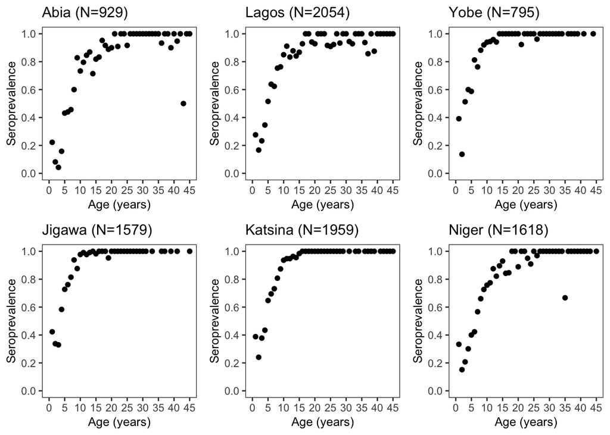

Let’s plot all the panels in a single pdf.

```r
states <- unique(pull(ng1_rub_sero_data, state)) %>% sort()
plots <- purrr::map(states, function(x) basic_serology_plot(x, ng1_rub_sero_data))

pdf(file.path(FIGURES_FOLDER, "basic_serology_plots.pdf"), w=8.5, h=11)
plots_per_page <- 20
groupings <- split(seq_along(plots), ceiling(seq_along(plots)/plots_per_page))
for (ii in seq_along(groupings)) {
  plots_subset <- plots[groupings[[ii]]]
  num_plots_subset <- length(plots_subset)
  if (num_plots_subset<plots_per_page) {
    for (jj in 1:(plots_per_page-num_plots_subset)) {
      plots_subset[[jj+num_plots_subset]] <- cowplot::ggdraw()
    }
  }
  print(cowplot::plot_grid(plotlist=plots_subset, ncol=4))
}
a <- dev.off()

# clean
rm(groupings, plots, plots_subset)
rm(a, ii, jj, num_plots_subset, plots_per_page)
```

## State-level estimation

### Force of infection

First, we estimate the force of infection in each state for the three age groups (i.e. 0-3 years, 3-15 years and 15+ years). We also simultaneously estimate the rate of loss of maternally-derived passive immunity in infants.

```r
compute_piecewise_lambda_fit <- function(group_id_data, sero_data, agegrps) {
  sero_data <- sero_data %>% left_join(group_id_data, by="state") %>% arrange(-desc(state), -desc(age))
  N <- nrow(sero_data)
  K <- length(unique(pull(sero_data, state)))
  gs <- sero_data %>% group_by(state) %>% summarise(count=length(state), .groups="keep") %>% pull(count)
  pos <- sero_data$positive
  tested <- sero_data$tested
  age <- sero_data$age
  agegrp_id <- findInterval(age-1, agegrps)
  num_agegrp <- length(agegrps)
  agegrp <- agegrps
  group_id <- pull(sero_data, group_id)[c(1, 1+cumsum(gs[-length(gs)]))]
  num_groups <- length(unique(group_id))
  input_data <- list(N=N, K=K, gs=gs, pos=pos, num_agegrp=num_agegrp, tested=tested, age=age,
                     agegrp_id=agegrp_id, num_agegrp=num_agegrp, agegrp=agegrp, group_id=group_id, num_groups=num_groups)
  init <- list(list(lambda=rnorm(K*num_agegrp-(K-num_groups), 0.1, 0.01)),
               list(lambda=rnorm(K*num_agegrp-(K-num_groups), 0.11, 0.01)),
               list(lambda=rnorm(K*num_agegrp-(K-num_groups), 0.12, 0.01)))
  fit <- stan(file=file.path(HELPER_SCRIPTS_FOLDER, "piecewise_lambda_fit.stan"),
              data = input_data, chains=3, init=init,
              warmup=2000, iter=4000, cores = 3, control = list(adapt_delta = 0.99), seed=100)
  return(fit)
}
agegrps <- c(0, 3, 15)
states <- unique(pull(ng1_rub_sero_data, state))
input <- data.frame(state=states, group_id=seq_along(states)) %>%
  mutate(group_id=ifelse(state %in% c("Taraba", "Adamawa"), group_id[which(state=="Taraba")], group_id)) %>%
  mutate(group_id=ifelse(state %in% c("Katsina", "Kano"), group_id[which(state=="Katsina")], group_id))
group_ids <- pull(input, group_id) %>% unique() %>% sort()
input$group_id <- sapply(input$group_id, function(x) which(group_ids==x))
```

Fitting the model to seroprevalence data…

```r
MCMC_piecewise_lambda_fit <- compute_piecewise_lambda_fit(group_id_data=input,
                                                          sero_data=ng1_rub_sero_data,
                                                          agegrps=agegrps)
saveRDS(MCMC_piecewise_lambda_fit,
        file=file.path(MCMC_FITTING_OUTPUT_FOLDER, "MCMC_piecewise_lambda_fit.rds"))
```

Loading the results of the fitting…

```r
MCMC_piecewise_lambda_fit <- readRDS(file.path(MCMC_FITTING_OUTPUT_FOLDER,
                                               "MCMC_piecewise_lambda_fit.rds"))
```

We first have to reformat the force of infection data.

```r
all_lambda_data <- rstan::extract(MCMC_piecewise_lambda_fit)[["lambda"]]
states <- unique(pull(ng1_rub_sero_data, state))
get_state_lambda <- function(this_state, num_age_grps, group_id_data) {
  state_pos <- which(this_state==sort(states))
  lambda_ids <- c((seq(1, num_age_grps-1, 1)-1)*length(states)+state_pos,
                  (num_age_grps-1)*length(states)+group_id_data[which(group_id_data$state==this_state), 2])

  state_lambda_data <- all_lambda_data[, lambda_ids]
  return(state_lambda_data)
}
state_lambda_data <- purrr::map(states, function(x) get_state_lambda(this_state=x,
                                                                     num_age_grps=3,
                                                                     group_id_data=input))
names(state_lambda_data) <- states
saveRDS(state_lambda_data, file=file.path(MCMC_ESTIMATES_FOLDER,
                                          "MCMC_piecewise_lambda_fit_lambda_estimates.rds"))
```

```r
state_lambda_data <- readRDS(file=file.path(MCMC_ESTIMATES_FOLDER,
                                            "MCMC_piecewise_lambda_fit_lambda_estimates.rds"))
```

Next, let’s plot the force of infection functions for each of the states:

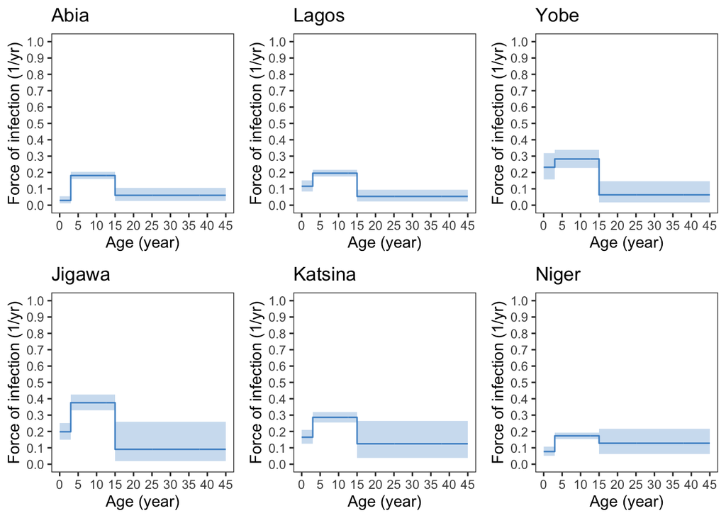

```r
focal_states <- c("Abia", "Lagos", "Yobe", "Jigawa", "Katsina", "Niger")
plots <- purrr::map(focal_states, function(x) foi_distribution_plot(x,
                                                                    state_lambda_data[[x]],
                                                                    age_groups=c(0, 3, 15, 45)))
cowplot::plot_grid(plots[[1]], plots[[2]], plots[[3]], plots[[4]], plots[[5]], plots[[6]],
                   nrow=2, ncol=3)
```

Let’s see whether the estimated force of infection estimates can replicate the actual data.

```r
focal_states <- c("Abia", "Lagos", "Yobe", "Jigawa", "Katsina", "Niger")
states <- unique(pull(ng1_rub_sero_data, state))
plots <- post_pred_dist_plot(focal_states,
                             MCMC_piecewise_lambda_fit,
                             ng1_rub_sero_data,
                             states=states)
```

[output not shown]

### Average period of materally-derived passive immunity

Let’s also retrieve and save the estimated rate of loss of maternally-acquired passive immunity for rubella across Nigeria.

```r
omegas <- rstan::extract(MCMC_piecewise_lambda_fit)[["delta"]]
saveRDS(omegas, file=file.path(MCMC_ESTIMATES_FOLDER,
                               "MCMC_piecewise_lambda_fit_omegas.rds"))
```

Let’s have quick look at the estimated distribution of the average period of maternally-acquired passive immunity for rubella across Nigeria.

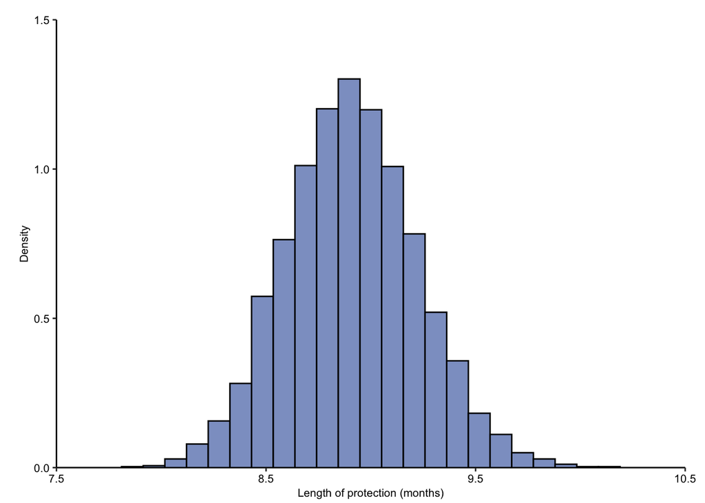

```r
avg_passive_immunity <- rstan::extract(MCMC_piecewise_lambda_fit)[["delta_inv"]] %>%
  as.data.frame() %>%
  setNames("avg_period")
mean_avg_passive_immunity <- mean(avg_passive_immunity$avg_period)*12
l90_avg_passive_immunity <- quantile(avg_passive_immunity$avg_period, 0.05)*12
u90_avg_passive_immunity <- quantile(avg_passive_immunity$avg_period, 0.95)*12
period_maternal_immunity <- ggplot() +
  geom_histogram(data=avg_passive_immunity, aes(x=avg_period*12, y=..density..),
                 fill="#8DA0CB", color="black", bins=30) +
  scale_x_continuous(breaks=seq(7.5, 10.5), limits=c(7.5, 10.5), expand=c(0, 0)) +
  scale_y_continuous(breaks=seq(0, 1.5, 0.5), limits=c(0, 1.5), expand=c(0, 0)) +
  labs(x="Length of protection (months)", y="Density") +
  theme_bw() +
  theme(panel.background=element_blank(), panel.border=element_blank(),
        axis.line.x.bottom = element_line(colour="black"),
        axis.line.y.left = element_line(colour="black"),
        panel.grid=element_blank(), plot.margin = unit(c(0.5, 0.5, 0.1, 0.5), "cm"),
        axis.text=element_text(size=8, colour="black"), axis.title=element_text(size=8, colour="black"))

print(period_maternal_immunity)
```

### Age-specific seropositivity

Let’s also retrieve the mean estimates for seropositivity in each age group for each state.

```r
states <- sort(unique(pull(ng1_rub_sero_data, state)))
all_seropos_estimates <- rstan::extract(MCMC_piecewise_lambda_fit)[["p"]]
seropos_list <- list()
state_pos <- 1
for (this_state in states) {
  ages <- ng1_rub_sero_data %>% filter(state==this_state) %>% pull(age)
  seropos <- colMeans(all_seropos_estimates[, state_pos:(state_pos+length(ages)-1)])
  seropos <- data.frame(age=ages, seropos=seropos)
  seropos_list[[this_state]] <- seropos
  state_pos <- state_pos + length(ages)
}
saveRDS(seropos_list, file=file.path(MCMC_ESTIMATES_FOLDER,
                                     "MCMC_piecewise_lambda_fit_mean_seropositivity_estimates.rds"))
```

Next, let’s compute the proportion of susceptibility among women of childbearing age.

```r
### computes the area under the curve for the function of the probability
### that an individual is susceptible at age a
compute_sus_prob_integral <- function(state_lambdas, agegrps, delta, left_endpoint, right_endpoint) {
  f <- function(x) {
    return(compute_prob_susceptible(lambdas=state_lambdas, a=x, agegrps=agegrps, delta=delta))
  }
  vec_f <- Vectorize(FUN=f, vectorize.args="x")
  sus_prob_integral <- integrate(vec_f, lower=left_endpoint, upper=right_endpoint)$value
  return(sus_prob_integral)
}

# compute the proportion of susceptible among women of childbearing age.
states <- unique(pull(ng1_fpop, state))
state_sus_prob_list <- list()
state_total_sus_prob_list <- list()
for (this_state in states) {
  print(this_state)
  state_ng1_fpop <- ng2_pop %>%
    filter(state==this_state) %>%
    group_by(agegrp) %>%
    summarise(n=sum(n, na.rm=TRUE), .groups="keep") %>%
    as.data.frame() %>%
    mutate(agegrp=as.numeric(as.character(agegrp))) %>%
    filter(agegrp>=15, agegrp<45) %>%
    arrange(-desc(agegrp))
  left_endpoints <- state_ng1_fpop %>% pull(agegrp)
  avg_sus_probs_list <- list()
  total_avg_sus_prob_list <- list()
  for (ii in 1:ncol(state_lambda_data[[this_state]])) {
    avg_sus_probs <- sapply(seq_along(left_endpoints),
                            function(x) compute_sus_prob_integral(state_lambdas=state_lambda_data[[this_state]][ii, ],
                                                                  agegrps=c(0, 3, 15),
                                                                  delta=omegas[ii],
                                                                  left_endpoint=left_endpoints[x],
                                                                  right_endpoint=left_endpoints[x]+5))/5
    avg_sus_probs_list[[ii]] <- avg_sus_probs*state_ng1_fpop$n/state_ng1_fpop$n*100
    total_avg_sus_prob_list[[ii]] <- sum(avg_sus_probs*state_ng1_fpop$n)/sum(state_ng1_fpop$n)*100
  }
  avg_sus_probs <- do.call(rbind, avg_sus_probs_list)
  total_avg_sus_probs <- do.call(c, total_avg_sus_prob_list)
  state_sus_prob_list[[this_state]] <- avg_sus_probs
  state_total_sus_prob_list[[this_state]] <- total_avg_sus_probs
}
saveRDS(state_total_sus_prob_list,
        file=file.path(MCMC_ESTIMATES_FOLDER,
                       "MCMC_piecewise_lambda_fit_percent_susceptible_childbearing_ages2.rds"))
saveRDS(state_sus_prob_list,
        file=file.path(MCMC_ESTIMATES_FOLDER,
                       "MCMC_piecewise_lambda_fit_percent_susceptible_childbearing_ages1.rds"))
```

Reading in the estimates for the percentage of women of child-bearing age that are suceptible to infection.

```r
state_total_sus_prob_list <- readRDS(
        file=file.path(MCMC_ESTIMATES_FOLDER,
                       "MCMC_piecewise_lambda_fit_percent_susceptible_childbearing_ages2.rds"))
state_sus_prob_list <- readRDS(
        file=file.path(MCMC_ESTIMATES_FOLDER,
                       "MCMC_piecewise_lambda_fit_percent_susceptible_childbearing_ages1.rds"))
```

Let’s plot the percentage of women of childbearing age (15-45 years) estimated to be susceptible to infection (i.e. no history of rubella infection).

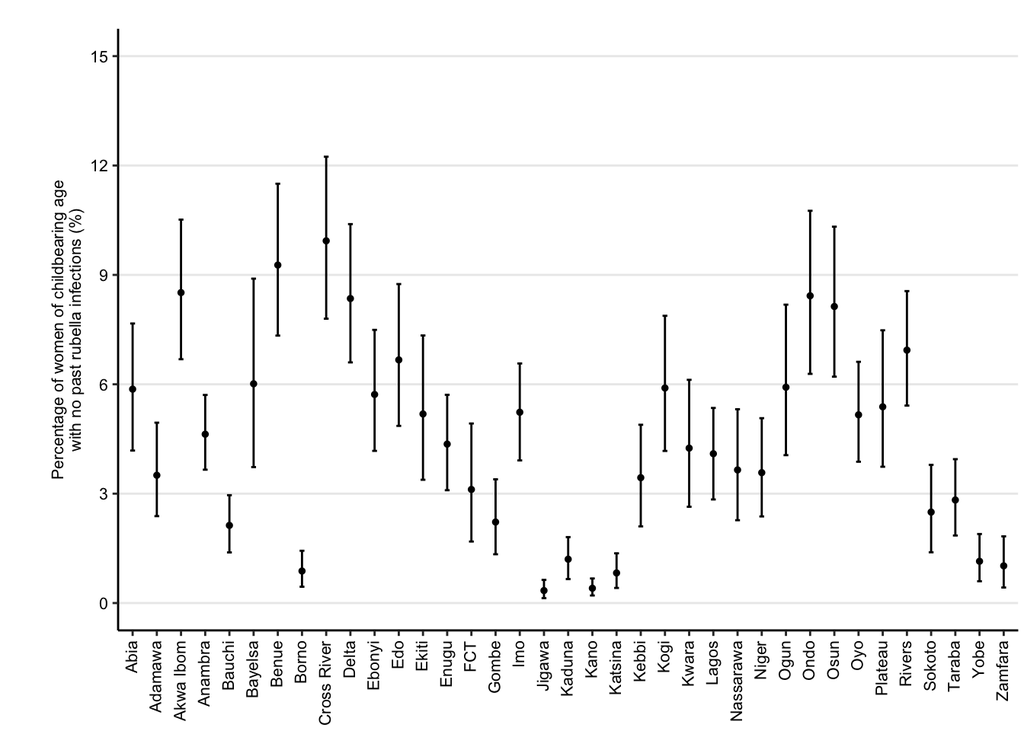

```r
# organize the data
state_order <- names(state_sus_prob_list)
state_sus_prob <- do.call(rbind, state_total_sus_prob_list) %>%
  data.frame() %>%
  cbind(state=state_order, .) %>%
  gather(key="sim", value="percentage_susceptible", 2:ncol(.)) %>%
  group_by(state) %>%
  summarise(mean=mean(percentage_susceptible),
            l90=quantile(percentage_susceptible, 0.05),
            u90=quantile(percentage_susceptible, 0.95), .groups="keep") %>%
  as.data.frame()
state_sus_prob[which(state_sus_prob=="Federal Capital Territory"), "state"] <- "FCT"

# plot
percentage_seroneg_plot <- ggplot(data=state_sus_prob) +
  geom_errorbar(aes(x=state, ymin=l90, ymax=u90), width=0.2) +
  geom_point(aes(x=state, y=mean), fill="black", color="black", shape=21, size=1) +
  scale_y_continuous(limits=c(0, 15), breaks=seq(0, 15, 3)) +
  labs(y="Percentage of women of childbearing age\nwith no past rubella infections (%)") +
  theme_bw() +
  theme(axis.title.x=element_blank(), axis.text.x=element_text(size=8, angle=90, vjust=0.4, hjust=1, color="black"),
        axis.title.y=element_text(color="black", size=8),
        axis.text.y=element_text(colour="black", size=8)) +
  theme(plot.margin=unit(c(0.5, 0.1, 0.1, 0.9), "cm"),
        panel.grid.minor=element_blank(), panel.grid.major.x=element_blank(),
        panel.background=element_blank(), panel.border=element_blank(),
        axis.line.x.bottom = element_line(colour="black"),
        axis.line.y.left = element_line(colour="black"))

print(percentage_seroneg_plot)
```

Next, let’s compute the number of pregnant women at risk of infection per year.

```r
# age-specific fertility rate data
ng1_asfr_data <- ng1_fertility_data %>%
    gather(key="agegrp", value="asfr", 2:ncol(.)) %>%
    mutate(agegrp=gsub("\\.", "-", gsub("X", "", agegrp)))
ng1_fpop <- ng2_pop %>%
  filter(gender=="f") %>%
  group_by(state, agegrp) %>%
  summarise(n=sum(n, na.rm=TRUE), .groups="keep") %>%
  ungroup() %>%
  mutate(agegrp=as.numeric(as.character(agegrp))) %>%
  mutate(agegrp=paste0(agegrp, "-", agegrp+4))
ng1_sus_prob <- purrr::map(names(state_sus_prob_list),
                                 function(x) {
                                   return(data.frame(state=x,
                                                     sim=1:nrow(state_sus_prob_list[[x]]),
                                                     state_sus_prob_list[[x]]))
                                 }) %>%
  do.call(rbind, .) %>%
  setNames(c("state", "sim", "15-19", "20-24", "25-29", "30-34", "35-39", "40-44")) %>%
  gather(key="agegrp", value="percent_sus", 3:ncol(.))
ng1_yearly_preg_at_risk <- ng1_asfr_data %>%
  inner_join(ng1_fpop, by=c("state", "agegrp")) %>%
  mutate(yearly_preg=n*asfr) %>%
  right_join(ng1_sus_prob, by=c("state", "agegrp")) %>%
  group_by(state, sim) %>%
  summarise(preg_at_risk=sum(yearly_preg*percent_sus/100), .groups="keep") %>%
  ungroup() %>% group_by(state) %>%
  summarise(mean=mean(preg_at_risk),
            l90=quantile(preg_at_risk, 0.05),
            u90=quantile(preg_at_risk, 0.95), .groups="keep") %>%
  ungroup() %>%
  left_join(ng1_zone_mapping, by="state")
```

Let’s plot the number of pregnant women at risk of rubella infection per year in each state.

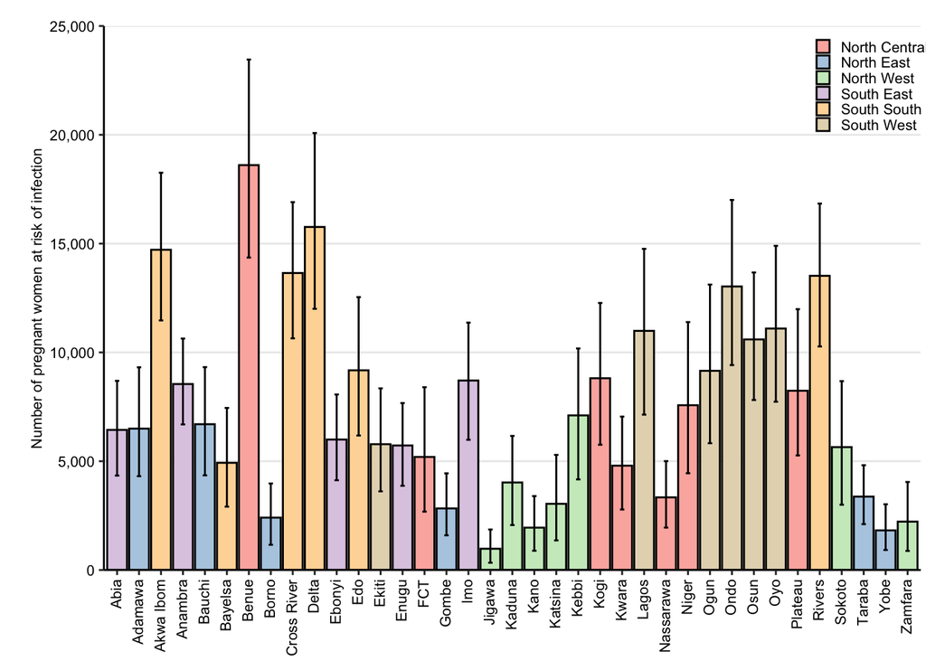

```r
zone_colors <- brewer.pal(8, "Pastel1")[c(1:5, 7)]
zone_order <- c("North Central", "North East", "North West", "South East", "South South", "South West")
ng1_yearly_preg_at_risk[which(ng1_yearly_preg_at_risk=="Federal Capital Territory"), "state"] <- "FCT"
pregnant_women_at_risk_plot <- ggplot(data=ng1_yearly_preg_at_risk) +
  geom_col(aes(x=state, y=mean, fill=zone), color="black") +
  geom_errorbar(aes(x=state, ymin=l90, ymax=u90), width=0.2) +
  scale_y_continuous(breaks=seq(0, 25000, 5000), limits=c(0, 25000), labels = comma_format(big.mark = ",",
                                           decimal.mark = "."), expand=c(0, 0)) +
  labs(y="Number of pregnant women at risk of infection") +
  scale_fill_manual(breaks=zone_order, values=zone_colors, guide=guide_legend(ncol=1)) +
  theme_bw() +
  theme(axis.title.x=element_blank(), axis.text.x=element_text(size=8, angle=90, vjust=0.4, hjust=1, color="black"),
        axis.title.y=element_text(size=8, color="black"), legend.title=element_blank(),
        legend.text=element_text(size=8),
        axis.text.y=element_text(colour="black", size=8)) +
  theme(legend.position = c(0.94, 0.9), legend.key.size=unit(0.3, "cm"),
        legend.background = element_blank(),
    legend.box.background = element_blank()) +
  theme(plot.margin=unit(c(0.5, 0.1, 0.1, 0.6), "cm"),
        panel.grid.minor=element_blank(), panel.grid.major.x=element_blank(),
        panel.background=element_blank(), panel.border=element_blank(),
        axis.line.x.bottom = element_line(colour="black"),
        axis.line.y.left = element_line(colour="black"))

print(pregnant_women_at_risk_plot)
```

Let’s combine the two above plots.

```r
pA <- percentage_seroneg_plot + theme(axis.text.x=element_blank())
pAB <- cowplot::plot_grid(pA, pregnant_women_at_risk_plot, ncol=1, labels=c("(a)", "(b)"),
                          label_size=10, label_fontface = "plain", label_fontfamily="serif", rel_heights=c(1, 1.2))
scale_factor <- 0.5
pdf(file=file.path(FIGURES_FOLDER, "rubella_epi_women_childbearing_age.pdf"), w=8.5, h=11*scale_factor)
print(pAB)
a <- dev.off()
```

### Mean age of infection

Next, let’s compute the mean age of infection in each state.

```r
### computes the area under the curve for the function of the probability
### that an individual is susceptible at age a
compute_sus_prob_integral <- function(state_lambdas, agegrps, delta, left_endpoint, right_endpoint) {
  f <- function(x) {
    return(compute_prob_susceptible(lambdas=state_lambdas, a=x, agegrps=agegrps, delta=delta))
  }
  vec_f <- Vectorize(FUN=f, vectorize.args="x")
  sus_prob_integral <- integrate(vec_f, lower=left_endpoint, upper=right_endpoint)$value
  return(sus_prob_integral)
}

# compute the mean age of infection in each age group
states <- unique(pull(ng1_fpop, state))
state_mean_age_inf_list <- list()
for (this_state in states) {
  print(this_state)
  mean_age_inf_list <- list()
  for (ii in 1:ncol(state_lambda_data[[this_state]])) {
    mean_age_inf <- compute_sus_prob_integral(state_lambdas=state_lambda_data[[this_state]][ii, ],
                                              agegrps=c(0, 3, 15),
                                              delta=omegas[ii],
                                              left_endpoint=0,
                                              right_endpoint=Inf)
    mean_age_inf_list[[ii]] <- mean_age_inf
  }
  state_mean_age_inf_list[[this_state]] <- do.call(c, mean_age_inf_list)
}
ng1_mean_age_inf <- do.call(cbind, state_mean_age_inf_list) %>%
  as.data.frame()
saveRDS(ng1_mean_age_inf,
        file=file.path(MCMC_ESTIMATES_FOLDER,
                       "MCMC_piecewise_lambda_fit_mean_age_inf_estimates.rds"))
```

Reading in the estimates for the mean age of infection in each state.

```r
ng1_mean_age_inf <- readRDS(
        file=file.path(MCMC_ESTIMATES_FOLDER,
                       "MCMC_piecewise_lambda_fit_mean_age_inf_estimates.rds"))
```

Let’s plot the distribution of the mean age of infection in each state.

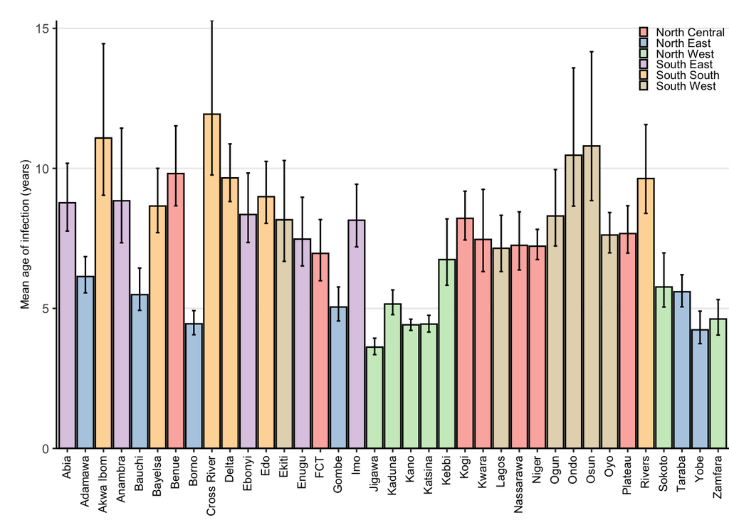

```r
mean_age_inf_data <- ng1_mean_age_inf %>%
  lapply(function(x) c(mean(x), l90=quantile(x, 0.05), u90=quantile(x, 0.95))) %>%
  do.call(rbind, .) %>%
  as.data.frame() %>%
  cbind(state=names(ng1_mean_age_inf), .) %>%
  setNames(c("state", "mean", "l90", "u90")) %>%
  left_join(ng1_zone_mapping, by="state")

zone_colors <- brewer.pal(8, "Pastel1")[c(1:5, 7)]
zone_order <- c("North Central", "North East", "North West", "South East", "South South", "South West")
mean_age_inf_data[which(mean_age_inf_data=="Federal Capital Territory"), "state"] <- "FCT"
mean_age_inf_plot <- ggplot(data=mean_age_inf_data) +
  geom_col(aes(x=state, y=mean, fill=zone), color="black") +
  geom_errorbar(aes(x=state, ymin=l90, ymax=u90), width=0.2) +
  scale_y_continuous(expand=c(0, 0)) +
  scale_fill_manual(breaks=zone_order, values=zone_colors, guide=guide_legend(ncol=1)) +
  labs(y="Mean age of infection (years)") +
  theme_bw() +
  theme(axis.title.x=element_blank(), axis.text.x=element_text(size=8, angle=90, vjust=0.4, hjust=1, color="black"),
        axis.title.y=element_text(size=8, color="black"), legend.title=element_blank(),
        legend.text=element_text(size=8)) +
  theme(legend.position = c(0.93, 0.92), legend.key.size=unit(0.23, "cm"),
        legend.background = element_blank(),
    legend.box.background = element_blank()) +
  theme(plot.margin=unit(c(0.5, 0, 0.1, 0.5), "cm"),
        panel.grid.minor=element_blank(), panel.grid.major.x=element_blank(),
        panel.background=element_blank(), panel.border=element_blank(),
        axis.line.x.bottom = element_line(colour="black"),
        axis.line.y.left = element_line(colour="black"))

print(mean_age_inf_plot)
```

### Basic reproductive number

Now, let’s attempt to estimate $R_0$. First, we need to compute the initial age distribution in each population.

```r
compute_initial_population <- function(pop_data, this_state, agegrps=c(0, 3, 15)) {
  state_pop_data <- pop_data %>%
    filter(state==this_state) %>%
    group_by(state, agegrp) %>%
    summarise(n=sum(n, na.rm=TRUE), .groups="keep") %>%
    as.data.frame() %>%
    mutate(agegrp=as.numeric(as.character(agegrp)))
  age5_pop <- state_pop_data[which(state_pop_data$agegrp==1), "n"]
  split_data <- data.frame(state=this_state,
                           agegrp=1:4,
                           n=age5_pop/4)
  state_pop_data <- state_pop_data %>%
    filter(agegrp!=1) %>%
    rbind(., split_data) %>%
    arrange(-desc(agegrp)) %>%
    mutate(interval=findInterval(agegrp, agegrps)) %>%
    group_by(state, interval) %>%
    summarise(n=sum(n), .groups="keep") %>%
    mutate(agegrp=agegrps[interval]) %>%
    as.data.frame()
  return(state_pop_data)
}
states <- unique(pull(ng1_rub_sero_data, state))
init_pop_list <- lapply(states, function(x) compute_initial_population(pop_data=ng2_pop, this_state=x))
names(init_pop_list) <- states
```

Now, we can estimate the $R_0$ in each state.

```r
agegrps <- c(0, 3, 15, Inf)
contact_mat <- matrix(c(1, 1, 3, 1, 2, 3, 3, 3, 3), nrow=3, ncol=3, byrow=TRUE)
deltas <- rstan::extract(MCMC_piecewise_lambda_fit)[["delta"]]
states <- unique(pull(ng1_rub_sero_data, state))
f <- function(this_state) {
  print(this_state)
  lambda_data <- state_lambda_data[[this_state]]
  N <- sum(ng2_pop[which(ng2_pop$state==ifelse(this_state=="FCT", "Federal Capital Territory", this_state)), "n"], na.rm=TRUE)
  initN <- init_pop_list[[ifelse(this_state=="FCT", "Federal Capital Territory", this_state)]] %>%
    arrange(-desc(agegrp)) %>%
    pull(n)
  mu <- ng0_selected_mortality_rates

  L <- compute_avg_life_exp(mu=mu, agegrps=agegrps[-length(agegrps)])
  equN <- sapply(1:(length(agegrps)-1), function(x)
                 compute_avg_life_exp(mu, agegrps=agegrps[-length(agegrps)], interval=c(agegrps[x], agegrps[x+1])))/L*N
  M_mat <- compute_M_mat(mu=mu, contact_mat=contact_mat, agegrps=agegrps)
  number_samples <- 2000
  for (tt in 1:number_samples) {
    beta_estimate <- compute_betas(lambdas=lambda_data[tt, ], mus=mu, delta=deltas[tt], agegrps=agegrps,
                                   initN=initN, equN=equN, N=N, L=L, D=10/365, contact_mat=contact_mat)
    saveRDS(beta_estimate, file=file.path(MCMC_ESTIMATES_FOLDER, "R0_beta_estimates", "tmp", paste0(this_state, "_beta_estimate", tt, ".rds")))
  }
  state_beta_estimates <- do.call(rbind, lapply(1:number_samples, function(x) readRDS(file.path(MCMC_ESTIMATES_FOLDER,
                                                                                              "R0_beta_estimates", "tmp", paste0(this_state, "_beta_estimate", x, ".rds")))))
  state_R0_estimates <- sapply(1:nrow(state_beta_estimates), function(x)
    compute_R0(agegrps=agegrps, initN=initN, equN=equN, N=N, L=L, D=10/365, contact_mat=contact_mat,
               betas=state_beta_estimates[x, ], M_mat=M_mat))
  state_estimates <- cbind(state_R0_estimates, state_beta_estimates)
  file_name <- paste0(this_state, "_R0_beta_estimates.rds")
  saveRDS(state_estimates, file=file.path(MCMC_ESTIMATES_FOLDER, "R0_beta_estimates", file_name))
  gc()
}
{parallel::mclapply(as.list(states), f, mc.cores=3)}
state_estimates <- lapply(states, function(x) readRDS(file=file.path(MCMC_ESTIMATES_FOLDER,
                                                                     "R0_beta_estimates",
                                                                     paste0(x, "_R0_beta_estimates.rds"))))
names(state_estimates) <- states
R0_estimates <- do.call(cbind, lapply(states, function(x) state_estimates[[x]][, 1]))
colnames(R0_estimates) <- states
beta_estimates_list <- lapply(states, function(x) state_estimates[[x]][, -1])
names(beta_estimates_list) <- as.character(states)
mu <-  ng0_selected_mortality_rates %>%
  rep(., each=length(states)) %>%
  matrix(, nrow=length(states), ncol=3) %>%
  as.data.frame() %>%
  setNames(c("mu1", "mu2", "mu3")) %>%
  mutate(state=states) %>%
  select(state, dplyr::everything())
saveRDS(R0_estimates,
        file=file.path(MCMC_ESTIMATES_FOLDER,
                       "MCMC_piecewise_lambda_fit_R0_estimates.rds"))
saveRDS(beta_estimates_list,
        file=file.path(MCMC_ESTIMATES_FOLDER,
                       "MCMC_piecewise_lambda_fit_beta_estimates.rds"))
saveRDS(list(agegrps=agegrps, contact_mat=contact_mat),
        file=file.path(MCMC_ESTIMATES_FOLDER,
                       "MCMC_piecewise_lambda_fit_contact_structure.rds"))
saveRDS(mu,
        file=file.path(MCMC_ESTIMATES_FOLDER,
                       "MCMC_piecewise_lambda_fit_mu_estimates.rds"))
```

Reading in the $R_0$ estimates folder:

```r
R0_estimates <- readRDS(
  file.path(MCMC_ESTIMATES_FOLDER,
            "MCMC_piecewise_lambda_fit_R0_estimates.rds"))
```

## National-level estimation

Next, we perform the same analysis but at the national level.

### Force of infection

First, we estimate the force of infection in each state for the three age groups (i.e. 0-3 years, 3-15 years and 15+ years). We also simultaneously estimate the rate of loss of materally-derived passive immunity in infants.

```r
agegrps <- c(0, 3, 15)
ng0_sero_data <- ng1_rub_sero_data %>%
  group_by(age) %>%
  summarise(positive=sum(positive), tested=sum(tested), .groups="keep") %>%
  ungroup() %>%
  arrange(-desc(age)) %>%
  mutate(state="Nigeria")
N <- nrow(ng0_sero_data)
pos <- ng0_sero_data$positive
tested <- ng0_sero_data$tested
age <- ng0_sero_data$age
num_agegrp <- length(agegrps)
agegrp <- agegrps
input_data <- list(N=N, pos=pos, num_agegrp=num_agegrp, tested=tested, age=age,
                   num_agegrp=num_agegrp, agegrp=agegrp)
init <- list(list(lambda=rnorm(num_agegrp, 0.1, 0.01)),
             list(lambda=rnorm(num_agegrp, 0.11, 0.01)),
             list(lambda=rnorm(num_agegrp, 0.12, 0.01)))
```

Fitting the data…

```r
ng0_MCMC_piecewise_lambda_fit <- stan(file=file.path(HELPER_SCRIPTS_FOLDER, "national_piecewise_lambda_fit.stan"),
                                      data = input_data, chains=3, init=init,
                                      warmup=2000, iter=4000, cores = 3,
                                      control = list(adapt_delta = 0.99), seed=100)
saveRDS(ng0_MCMC_piecewise_lambda_fit,
        file=file.path(MCMC_FITTING_OUTPUT_FOLDER,
                       "ng0_MCMC_piecewise_lambda_fit.rds"))
```

Loading the fitting data…

```r
ng0_MCMC_piecewise_lambda_fit <- readRDS(file=file.path(MCMC_FITTING_OUTPUT_FOLDER,
                                                        "ng0_MCMC_piecewise_lambda_fit.rds"))
```

Let’s plot the force of infection function:

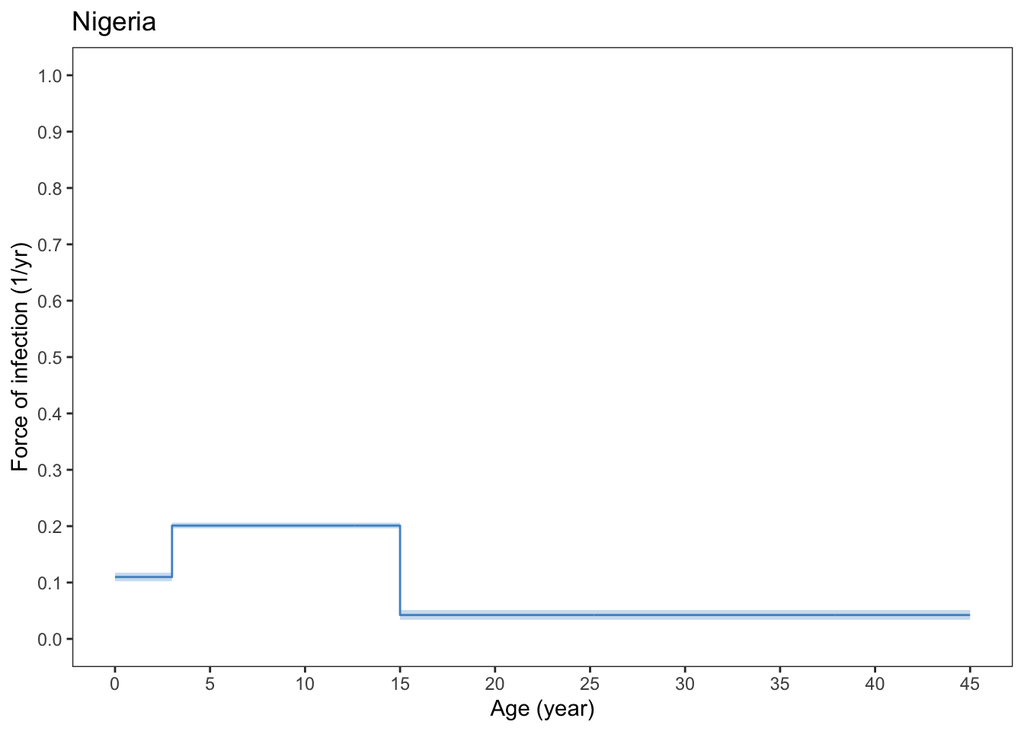

```r
ng0_lambda_data <- rstan::extract(ng0_MCMC_piecewise_lambda_fit)[["lambda"]]
saveRDS(ng0_lambda_data, file.path(MCMC_ESTIMATES_FOLDER,
                                   "ng0_MCMC_piecewise_lambda_fit_lambda_estimates.rds"))
foi_distribution_plot("Nigeria", ng0_lambda_data, age_groups=c(0, 3, 15, 45))
```

Let’s see whether the estimated force of infection estimates can replicate the actual data.

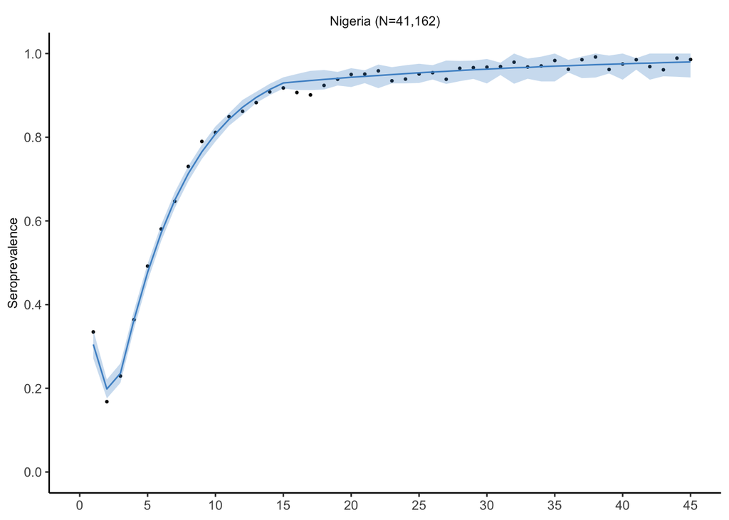

```r
post_pred_dist_plot("Nigeria", MCMC_fit=ng0_MCMC_piecewise_lambda_fit, sero_data=ng0_sero_data, states="Nigeria")
```

### Average period of materally-derived passive immunity

Let’s also retrieve and save the estimated rate of loss of maternally-acquired passive immunity for rubella across Nigeria.

```r
omegas <- rstan::extract(ng0_MCMC_piecewise_lambda_fit)[["delta"]]
saveRDS(omegas, file=file.path(MCMC_ESTIMATES_FOLDER,
                               "ng0_MCMC_piecewise_lambda_fit_omegas.rds"))
```

### Age-specific seropositivity

Let’s also retrieve the mean estimates for seropositivity in each age group for each state.

```r
ng0_seropos_estimates <- rstan::extract(ng0_MCMC_piecewise_lambda_fit)[["p"]]
ages <- ng0_sero_data$age
ng0_seropos <- colMeans(ng0_seropos_estimates)
ng0_seropos <- data.frame(age=ages, seropos=ng0_seropos)
saveRDS(ng0_seropos, file=file.path(MCMC_ESTIMATES_FOLDER,
                                    "ng0_MCMC_piecewise_lambda_fit_mean_seropositivity_estimates.rds"))
```

### Basic reproductive number

Now, let’s attempt to estimate $R_0$. First, we need to compute the initial age distribution in each population.

```r
ng0_init_pop <- do.call(rbind, init_pop_list) %>%
  as.data.frame() %>%
  group_by(interval, agegrp) %>%
  summarise(n=sum(n), .groups="keep") %>%
  as.data.frame()
```

Now, we can estimate the $R_0$ in each state.

```r
agegrps <- c(0, 3, 15, Inf)
contact_mat <- matrix(c(1, 1, 3, 1, 2, 3, 3, 3, 3), nrow=3, ncol=3, byrow=TRUE)
deltas <- rstan::extract(ng0_MCMC_piecewise_lambda_fit)[["delta"]]
N <- sum(ng0_init_pop$n)
initN <- ng0_init_pop$n
mu <- ng0_selected_mortality_rates
L <- compute_avg_life_exp(mu=mu, agegrps=agegrps[-length(agegrps)])
equN <- sapply(1:(length(agegrps)-1), function(x)
  compute_avg_life_exp(mu, agegrps=agegrps[-length(agegrps)], interval=c(agegrps[x], agegrps[x+1])))/L*N
M_mat <- compute_M_mat(mu=mu, contact_mat=contact_mat, agegrps=agegrps)
beta_estimates_list <- list()
estimate_beta <- function(tt) {
  beta_estimate <- compute_betas(lambdas=ng0_lambda_data[tt, ], mus=mu,
                                 delta=deltas[tt], agegrps=agegrps,
                                 initN=initN, equN=equN, N=N, L=L, D=10/365,
                                 contact_mat=contact_mat)
  saveRDS(beta_estimate, file=file.path(MCMC_ESTIMATES_FOLDER, "R0_beta_estimates",
                                        "tmp", paste0("Nigeria", "_beta_estimate", tt, ".rds")))
}
number_samples <- 2000
{parallel::mclapply(as.list(1:number_samples), estimate_beta, mc.cores=3)}
ng0_beta_estimates <- do.call(rbind, lapply(1:number_samples, function(x)
  readRDS(file.path(MCMC_ESTIMATES_FOLDER, "R0_beta_estimates", "tmp",
                    paste0("Nigeria", "_beta_estimate", x, ".rds"))))) %>%
  as.data.frame() %>%
  setNames(c("beta1", "beta2", "beta3"))
ng0_R0_estimates <- sapply(1:nrow(ng0_beta_estimates), function(x)
  compute_R0(agegrps=agegrps, initN=initN, equN=equN, N=N, L=L, D=10/365, contact_mat=contact_mat,
             betas=as.numeric(ng0_beta_estimates[x, ]), M_mat=M_mat))

saveRDS(ng0_R0_estimates,
        file=file.path(MCMC_ESTIMATES_FOLDER,
                       "ng0_MCMC_piecewise_lambda_fit_R0_estimates.rds"))
saveRDS(ng0_beta_estimates,
        file=file.path(MCMC_ESTIMATES_FOLDER,
                       "ng0_MCMC_piecewise_lambda_fit_beta_estimates.rds"))
```

## Summary figures

In this section, we generate additional summary figures.

Let’s start by plotting the force of infection functions for each state.

```r
states <- unique(pull(ng1_rub_sero_data, state)) %>% sort()
plots <- purrr::map(states, function(x) foi_distribution_plot(this_state=x,
                                                              lambdas=state_lambda_data[[x]],
                                                              age_groups=c(0, 3, 15, 45),
                                                              ymax=0.5))

pdf(file.path(FIGURES_FOLDER, "foi_distribution_plot.pdf"), w=8.5, h=11)
plots_per_page <- 12
groupings <- split(seq_along(plots), ceiling(seq_along(plots)/plots_per_page))
for (ii in seq_along(groupings)) {
  plots_subset <- plots[groupings[[ii]]]
  num_plots_subset <- length(plots_subset)
  if (num_plots_subset<plots_per_page) {
    for (jj in 1:(plots_per_page-num_plots_subset)) {
      plots_subset[[jj+num_plots_subset]] <- cowplot::ggdraw()
    }
  }
  print(cowplot::plot_grid(plotlist=plots_subset, ncol=3))
}
a <- dev.off()
```

Next, let’s have a look at the posterior predictive distributions of the seroprevalence data.

```r
all_states <- unique(pull(ng1_rub_sero_data, state)) %>% sort()
all_states <- c(all_states, "Nigeria")
plots_per_page <- 24
groupings <- split(seq_along(all_states), ceiling(seq_along(all_states)/plots_per_page))
for (ii in seq_along(groupings)) {
  plots <- post_pred_dist_plot(these_states=all_states[groupings[[ii]]],
                               MCMC_fit=MCMC_piecewise_lambda_fit,
                               sero_data=ng1_rub_sero_data,
                               ng0_MCMC_fit=ng0_MCMC_piecewise_lambda_fit,
                               ng0_sero_data=ng0_sero_data,
                               states=setdiff(all_states, "Nigeria"))

  scale_factor <- length(states[groupings[[ii]]])/plots_per_page*0.8
  file_name <- paste0("post_pred_dist_plot", ii, ".pdf")
  pdf(file=file.path(FIGURES_FOLDER, file_name), w=8, h=11*scale_factor)
  print(plots)
  a <- dev.off()
}
```

Let’s create a plot for the distribution of the mean force of infection function in each state.

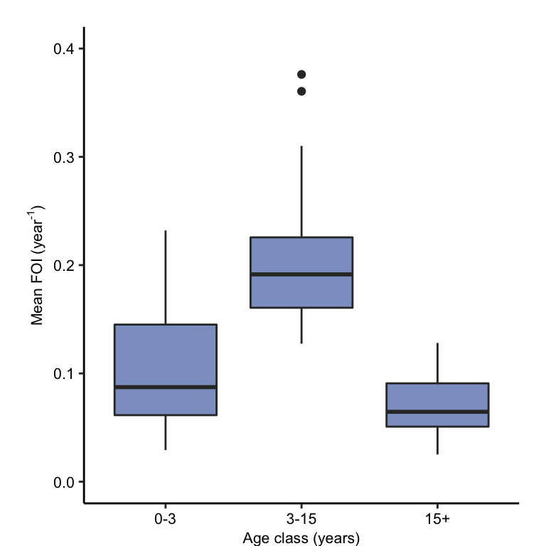

```r
state_lambda_summaries <- state_lambda_data %>%
  lapply(., function(x) apply(x, 2, function(x) mean(x))) %>%
  do.call(rbind, .) %>%
  as.data.frame() %>%
  setNames(c("lambda1", "lambda2", "lambda3")) %>%
  mutate(state=names(state_lambda_data)) %>%
  select(state, dplyr::everything()) %>%
  gather(key="lambda", value="mean", 2:ncol(.)) %>%
  mutate(lambda=factor(lambda, c("lambda1", "lambda2", "lambda3")))
ng0_lambda_summary <- ng0_lambda_data %>%
  as.data.frame() %>%
  setNames(c("lambda1", "lambda2", "lambda3")) %>%
  gather(key="agegrp", value="lambda", 1:ncol(.)) %>%
  group_by(agegrp) %>%
  summarise(mean=mean(lambda),
            l95=quantile(lambda, 0.05),
            u95=quantile(lambda, 0.95), .groups="keep") %>%
  as.data.frame() %>%
  mutate(agegrp=factor(agegrp, c("lambda1", "lambda2", "lambda3")))

lambda_summary_plot <- ggplot(data=state_lambda_summaries) +
  geom_boxplot(mapping=aes(x=lambda, y=mean), fill="#8DA0CB") +
  labs(y=expression(paste("Mean FOI (", year^{"-1"}, ")")), x="Age class (years)") +
  scale_y_continuous(limits=c(0, 0.4), breaks=seq(0, 0.4, 0.1)) +
  scale_x_discrete(labels=c("0-3", "3-15", "15+")) +
  theme_bw() +
  theme(axis.text=element_text(size=8, color="black"), axis.title=element_text(size=8, color="black")) +
  theme(plot.margin=unit(c(0.5, 0.5, 0, 0.5), "cm"),
        panel.grid=element_blank(),
         panel.background=element_blank(), panel.border=element_blank(),
        axis.line.x.bottom = element_line(colour="black"),
        axis.line.y.left = element_line(colour="black"))

print(lambda_summary_plot)
```

Let’s plot the estimates of the effective contact rates (i.e. $\beta$).

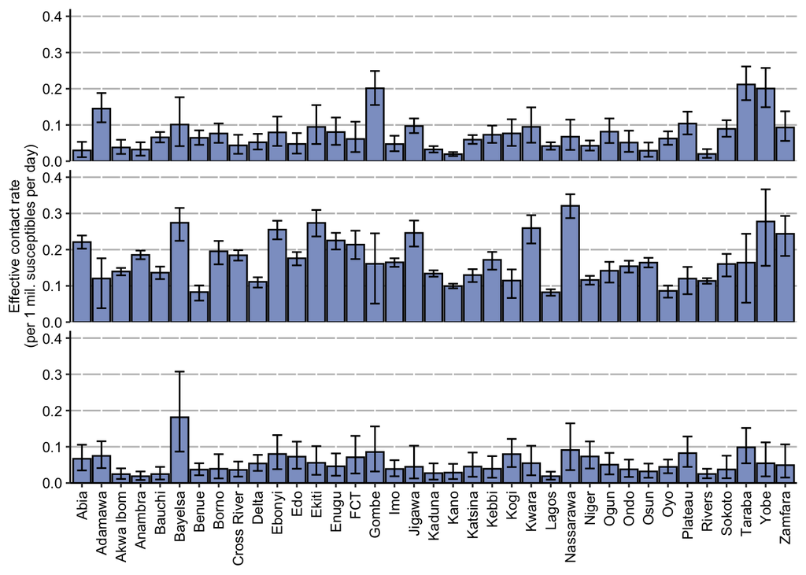

```r
beta_estimates_list <- readRDS(file=file.path(MCMC_ESTIMATES_FOLDER,
                                              "MCMC_piecewise_lambda_fit_beta_estimates.rds"))
num_beta <- 3
states <- unique(pull(ng1_rub_sero_data, state)) %>% sort()
org_beta_data <- list()
jj <- 1
for (ii in 1:num_beta) {
  for (this_state in states) {
    beta_values <- beta_estimates_list[[this_state]][, ii]/365
    mean_beta <- mean(beta_values)
    l90_beta <- quantile(beta_values, 0.05)
    u90_beta <- quantile(beta_values, 0.95)
    state_data <- data.frame(state=this_state, beta=paste0("beta", ii), mean=mean_beta, l90=l90_beta, u90=u90_beta)
    org_beta_data[[jj]] <- state_data
    jj <- jj + 1
  }
}
org_beta_data <- do.call(rbind, org_beta_data) %>%
  as.data.frame() %>%
  left_join(ng1_zone_mapping, by="state")
org_beta_data[which(org_beta_data$state=="Federal Capital Territory"), "state"] <- "FCT"

zone_colors <- brewer.pal(9, "Set1")[c(1:5, 7)]
zone_order <- c("North Central", "North East", "North West", "South East", "South South", "South West")
strip_labels <- c(expression(paste(beta)))
beta_estimates_summary_plot <- ggplot(data=org_beta_data) +
  geom_col(mapping=aes(x=state, y=mean*10^6), color="black", fill="#8DA0CB") +
  geom_errorbar(mapping=aes(x=state, ymin=l90*10^6, ymax=u90*10^6), width=0.5) +
  scale_y_continuous(limits=c(0, 0.42), breaks=seq(0, 0.4, 0.1), expand=c(0, 0)) +
  labs(y="Effective contact rate\n(per 1 mil. susceptibles per day)") +
  theme(axis.text.x=element_text(angle=90, hjust=1, vjust=0.5, color="black", size=9), axis.title.x=element_blank(),
        axis.text.y=element_text(color="black", size=9),
        axis.title.y=element_text(color="black", size=9),
        panel.border=element_rect(colour="black", fill=NA), strip.placement="outside",
        panel.background=element_rect(fill="white"), panel.grid.major.y=element_line(colour="grey"),
        strip.background = element_blank(), strip.text=element_blank()) +
  theme(panel.border=element_blank(), panel.background=element_blank(),
        axis.line.x.bottom=element_line(colour="black"), axis.line.y.left=element_line(colour="black"),
        plot.margin=margin(0.2, 0.2, 0.2, 0.2, unit="cm")) +
  facet_wrap(~beta, ncol=1, strip.position="right", labeller=labeller(beta=c("beta1"="Group 1", "beta2"="Group 2", "beta3"="Group 3")))

scale_factor <- 0.5
pA <- beta_estimates_summary_plot
pdf(file=file.path(FIGURES_FOLDER, "state_beta_plot.pdf"), w=8.5, h=11*scale_factor)
print(pA)
a <- dev.off()

print(beta_estimates_summary_plot)
```

Now, let’s plot the $R_0$ estimates along with the $90\%$ credible interval for each state.

```r
ng0_R0_estimates <- readRDS(file.path(MCMC_ESTIMATES_FOLDER,
                                      "ng0_MCMC_piecewise_lambda_fit_R0_estimates.rds"))
state_R0_estimates <- readRDS(file.path(MCMC_ESTIMATES_FOLDER,
                                        "MCMC_piecewise_lambda_fit_R0_estimates.rds"))
ng0_R0_summary <- ng0_R0_estimates %>%
  data.frame(R0=.) %>%
  mutate(state="Nigeria") %>%
  group_by(state) %>%
  summarise(mean=mean(R0),
            l90=quantile(R0, 0.05),
            u90=quantile(R0, 0.95), .groups="keep") %>%
  as.data.frame() %>%
  mutate(geometry=NA)

states <- unique(pull(ng1_rub_sero_data, state)) %>% sort()
states[which(states=="Federal Capital Territory")] <- "FCT"
state_R0_summaries <- state_R0_estimates %>%
  apply(2, function(x) c(mean(x), as.numeric(quantile(x, c(0.05, 0.95))))) %>%
  t() %>%
  cbind(states, .) %>%
  as.data.frame() %>%
  setNames(c("state", "mean", "l90", "u90")) %>%
  mutate(mean=as.numeric(mean), l90=as.numeric(l90), u90=as.numeric(u90)) %>%
  right_join(mutate(ng1, state=ifelse(state=="Federal Capital Territory", "FCT", state)),
             by="state") %>%
  rbind(., ng0_R0_summary)
```

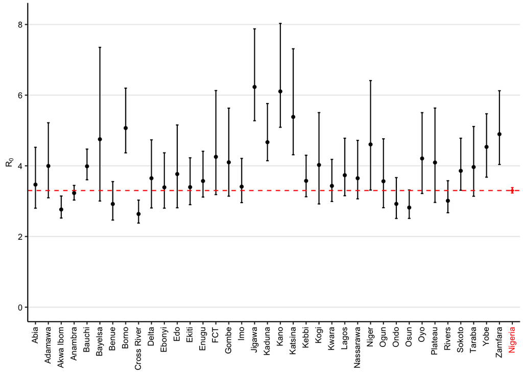

```r
state_order <- c(states, "Nigeria")
state_R0_summaries %<>% mutate(state=factor(state, state_order))

state_R0_summary_plot <- ggplot() +
  geom_errorbar(data=state_R0_summaries, aes(x=state, ymin=l90, ymax=u90, color=state), width=0.2) +
  geom_point(data=state_R0_summaries, aes(x=state, y=mean, color=state, fill=state, shape=state), size=1.5) +
  geom_hline(yintercept=ng0_R0_summary$mean, linetype="dashed", color="red") +
  scale_color_manual(breaks=state_order, values=c(rep("black", length(states)), "red"), guide="none") +
  scale_fill_manual(breaks=state_order, values=c(rep("black", length(states)), "red"), guide="none") +
  scale_shape_manual(breaks=state_order, values=c(rep(16, length(states)), 18), guide="none") +
  scale_y_continuous(limits=c(0, 8.2), breaks=seq(0, 8, 2)) +
  labs(y=expression(paste(R[0]))) +
  theme_bw() +
  theme(axis.title.x=element_blank(),
        axis.text.x=element_text(size=8, angle=90, vjust=0.4, hjust=1,
                                 colour=c(rep("black", length(states)), "red")),
        axis.title.y=element_text(color="black", size=8),
        axis.text.y=element_text(colour="black", size=8)) +
  theme(plot.margin=unit(c(0.1, 0.1, 0.1, 0.2), "cm"),
        panel.grid.major.x=element_blank(), panel.grid.minor.y=element_blank(),
         panel.background=element_blank(), panel.border=element_blank(),
        axis.line.x.bottom = element_line(colour="black"),
        axis.line.y.left = element_line(colour="black"))
print(state_R0_summary_plot)
```

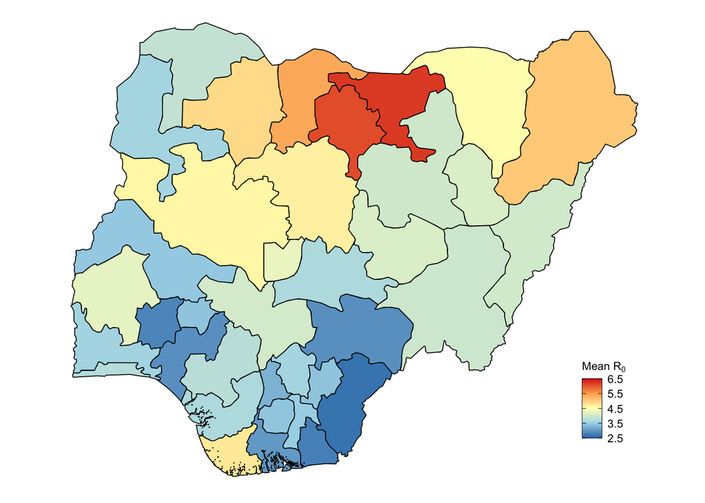

```r
color_scale <- rep(rev(brewer.pal(5, "RdYlBu")), each=10)
state_R0_summary_map <- state_R0_summaries %>%
  filter(state!="Nigeria") %>%
  ggplot() +
  geom_sf(mapping=aes(geometry=geometry, fill=mean), color="black", size=0.3) +
 scale_fill_gradientn(colors=rep(rev(brewer.pal(5, "RdYlBu")), each=1), breaks=seq(2.5, 6.5, 1), limits=c(2.5, 6.5),
                       name=expression(paste("Mean ", R[0], sep=""))) +
  theme_bw() +
  guides(fill=guide_colorbar(title.position="top", title.hjust=0.5,
                             ticks.colour="black", frame.colour="black")) +
  theme(panel.grid.major=element_blank(), panel.grid.minor=element_blank(),
        panel.background=element_blank(), panel.border=element_blank(),
        axis.line=element_blank(), axis.ticks=element_blank(), axis.text=element_blank(),
        axis.title=element_blank()) +
  theme(legend.position=c(0.9, 0.2), legend.key.size=unit(0.3, "cm"), legend.key.width=unit(0.5, "cm"),
        legend.text=element_text(size=8), legend.title=element_text(size=8),
        legend.box.background=element_blank(), legend.background=element_blank()) +
  theme(plot.margin=unit(c(0, 0, 0, 0), "cm"))
print(state_R0_summary_map)
```

Let’s create a map of the states in Nigeria.

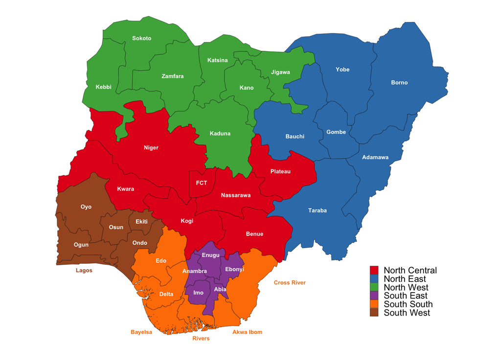

```r
zone_colors <- brewer.pal(9, "Set1")[c(1:5, 7)]
zone_order <- c("North Central", "North East", "North West", "South East", "South South", "South West")
mod_ng1 <- ng1 %>%
  left_join(ng1_zone_mapping, by="state") %>%
  mutate(x=st_coordinates(st_centroid(geometry))[,1], y=st_coordinates(st_centroid(geometry))[,2]) %>%
  mutate(state=ifelse(state=="Federal Capital Territory", "FCT", state))
state_names <- unique(pull(mod_ng1, state))
x_adj <- c(0.2, 0, 0.7, 0, 0, -0.8, 0, 0, 1.25, 0.1, 0.15, 0, 0, 0, 0, 0, 0, 0, 0, 0, 0, -0.35, 0, 0.45, 0, 0, 0, 0,
           0.1, 0, 0, 0, 0.2, 0, -0.15, 0, 0)
y_adj <- c(0.2, 0.3, -0.55, 0, -0.5, -0.4, 0, 0, 0, -0.2, 0, -0.1, 0, 0.15, 0, 0, 0, 0, 0, 0, 0.2, 0, 0, -0.3, -0.3, 0, 0, 0,
           0.15, 0, 0, 0, -0.69, 0.2, 0, 0, 0)
color <- c("white", "white", zone_colors[5], "white", "white", zone_colors[5], "white", "white",
           zone_colors[5], "white", "white", "white", "white", "white", "white", "white", "white",
           "white", "white", "white", "white", "white", "white", "white", zone_colors[6], "white",
           "white", "white", "white", "white", "white", "white", zone_colors[5], "white", "white",
           "white", "white")
mod_ng1 %<>%
   left_join(data.frame(state=state_names, x_adj=x_adj, y_adj=y_adj, color=color), by="state")
state_zone_map <- ggplot(data=mod_ng1) +
  geom_sf(mapping=aes(geometry=geometry, fill=zone), color="black", lwd=0.1) +
  geom_text(mapping=aes(x=x+x_adj, y=y+y_adj, label=state), size=2, color=color, fontface="bold") +
  scale_fill_manual(breaks=zone_order, values=zone_colors, name="") +
  theme_bw() +
  theme(legend.position="bottom", legend.box.just = "center", legend.margin = margin(6, 6, 6, 6)) +
  guides(fill=guide_legend(ncol=1)) +
  theme(panel.grid.major=element_blank(), panel.grid.minor=element_blank(),
        panel.background=element_blank(), panel.border=element_blank(),
        axis.line=element_blank(), axis.ticks=element_blank(), axis.text=element_blank(),
        axis.title=element_blank()) +
  theme(legend.position=c(0.85, 0.2), legend.key.size=unit(0.3, "cm"), legend.key.width=unit(0.3, "cm"),
        legend.text=element_text(size=9, color="black"),
        legend.box.background=element_blank(), legend.background=element_blank()) +
  theme(plot.margin = unit(c(0, 0, 0, 0), "cm"))
print(state_zone_map)
```

Let’s create a summary plot for the basic reproductive number.

```r
pAB <- cowplot::plot_grid(state_zone_map, state_R0_summary_map, nrow=1, labels=c("A", "B"))
pD <- cowplot::plot_grid(lambda_summary_plot, NULL, ncol=1, rel_heights=c(1, 0.7))
pCD <- cowplot::plot_grid(state_R0_summary_plot, pD, nrow=1, rel_widths=c(1, 0.4), labels=c("C", "D"))
pABCD <- cowplot::plot_grid(pAB, pCD, ncol=1)
scale_factor <- 0.6
pdf(file=file.path(FIGURES_FOLDER, "R0_estimation_summary_plot.pdf"), w=8.5, h=11*scale_factor)
print(pABCD)
a <- dev.off()
```

Let’s create another potential summary plot for the basic reproductive number.

```r
pAB <- cowplot::plot_grid(state_R0_summary_plot, state_R0_summary_map, nrow=1, labels=c("(a)", "(b)"),
                          rel_widths=c(1, 0.4), label_size=10, label_fontface="plain", label_fontfamily="serif")
scale_factor <- 0.22
pdf(file=file.path(FIGURES_FOLDER, "truncated_R0_estimation_summary_plot.pdf"), w=8.5, h=11*scale_factor)
print(pAB)
a <- dev.off()
```

Let’s create a summary plot for the age-dependent risk of infection.

```r
pBC <- cowplot::plot_grid(lambda_summary_plot, period_maternal_immunity, ncol=1, labels=c("(b)", "(c)"),
                          label_size=10, label_fontface = "plain", label_fontfamily="serif")
pABC <- cowplot::plot_grid(mean_age_inf_plot, pBC, nrow=1, labels=c("(a)", ""), rel_widths=c(1, 0.45),
                           label_size=10, label_fontface = "plain", label_fontfamily="serif")

scale_factor <- 0.3
pdf(file=file.path(FIGURES_FOLDER, "age_dependent_risk_infection.pdf"), w=8.5, h=11*scale_factor)
print(pABC)
a <- dev.off()
```